### Assumptions

Assumptions - When broken then we are not able to make inference or accurate descriptions about reality.

Thus our models are flawed descriptions and inferences will be compromised.

- Assumptions of parametric tests based on the normal distribution.
- Understand the assumption of normality.
- Understand homogeneity of variance.
- Know how to correct problems (with respect to the assumptions of normality) in the data.

Parametric tests based on the normal distribution assume:

- Normally distributed
- Distribution of samples
- Model distribution (residuals)
- Homogeneity of variance
- Interval or ratio level data
- Some data are intrinsically not normally distributed.
- Independence of observation

### The Normal Distribution Review

Commonly the distribution of measurements (frequency of data collected from interval data) have a bell shaped distribution

Parameters of the model determine its shape.

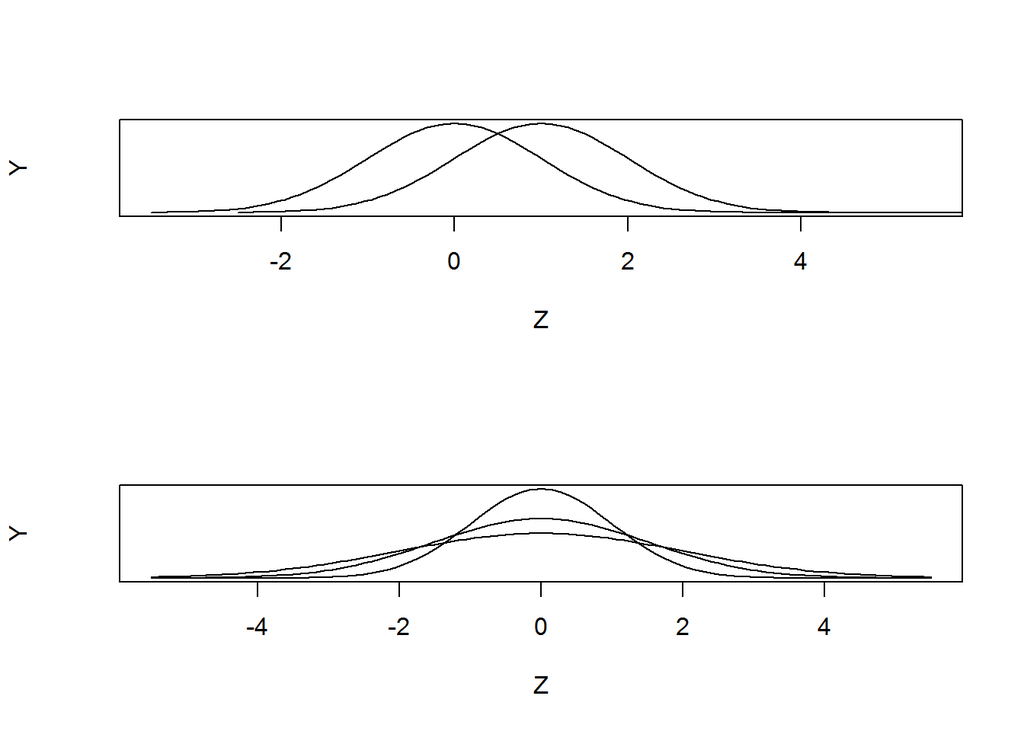

*Figure 4.12.1*

Two-parameter distribution

$f(x,\mu,\sigma)=\frac{1}{\sigma\sqrt2\pi}e^-(x-\mu)^2/2\sigma^2$

Symmetric around mu

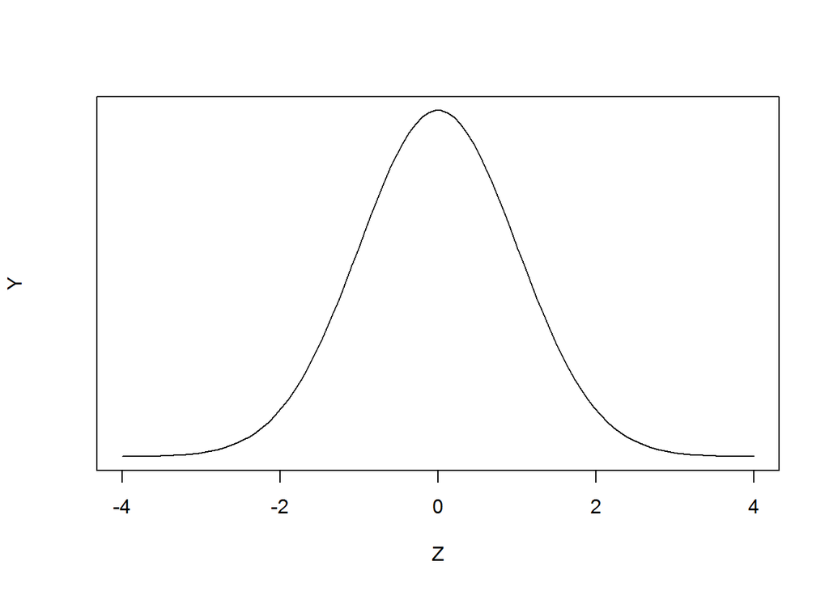

*Figure 4.12.2*

### 4.13 Distribution of Samples Central Limit Theorem

How well do samples represent the population?

A key foundation of frequentist statistics - samples are random variables: When we take a sample from the population we are taking one of many possible samples.

Thought experiment - take many, many samples from a population.

Do we expect all sample to have the same mean value (the same sample mean)?

- No, there is variation in the samples - ‘Sampling variation.’

The frequency histogram of samples is the sampling distribution.

Analog to standard deviation

- SD how well does model fit the data

We can take the standard deviation of the sample mean.

- Termed ‘Standard Error of the Sampling mean’
- Or ‘Standard Error’

If the sample is large then sampling error can be approximated:

$SE=\frac{s}{\sqrt n}$

### 4.14 Assumption #1: Sample observations and associated deviations are normally distributed.

We will review how to check these assumptions in this lecture and the following lab.

### 4.15 Assumption #2: Homogeneity of Variance.

Data taken from groups must have homogenous variance.

Homogenous does not mean ‘equal’ but equal in the probabilistic sense.

We will review how to check these assumptions in this lecture and the following lab.

### 4.16 Assumption #3: Interval and Ratio Scale

Continuous variables

- Interval scale (equal intervals between measurements).
- Ratio scale - Conversion of interval data such that ratio of measurements was meaningful.

Ordinal data - rankings -

- Darker, faster, shorter and might label these 1,2,3,4,5 to reflect increases in magnitude.
- Really convey less information - data condensation.

Nominal or Categorical data

- Example are public surveys
- Willingness to vote for a candidate? Economic class, Taxonomic categories.

### 4.17 Assumption #4

Observations are independent

The measurement of one sample does not influence the measurement of another sample.

- Measurements taken in space and time are examples - experimenter needs to determine when there is zero correlation between the samples.
- Behavioral Example - the opinion of one person influences the behavior of another person and hence the measurements are correlated.

### 4.18 Assessing Normality

We don’t have access to the population distribution so we usually test the observed data

Graphical displays

- Q-Q plot (or P-P plot)
- Histogram

Kolmogorov-Smirnov

Shapiro-Wilk

### 4.19 Assessing Homogeneity of Variance

Figures

Levene’s test

- Tests if variances in different groups are the same.
- Significant = variances not ‘equal’
- Non-significant = variances are ‘equal’

Variance ratio

- With 2 or more groups
- VR = largest variance/smallest variance
- If VR < 2, homogeneity can be assumed

### 4.20 Correcting Data ‘Problems’

Log transformation log(X<sub>i</sub>) or log(X<sub>i</sub> +1)

- Reduce positive skew.

Square root transformation:

- Also reduces positive skew. Can also be useful for stabilizing variance.

Reciprocal transformation (1/ X<sub>i</sub>):

- Dividing 1 by each score also reduces the impact of large scores.
- This transformation reverses the scores
- You can avoid this by reversing the scores before the transformation, 1/(X<sub>Highest</sub> - X<sub>i</sub>).

### 4.21 To Transform Or Not

Transforming the data helps as often as it hinders the accuracy of F

The central limit theorem: sampling distribution will be normal in samples > 40 anyway.

- Transforming the data changes the hypothesis being tested.
- E.g. when using a log transformation and comparing means, you change from comparing arithmetic means to comparing geometric means.
- In small samples it is tricky to determine normality one way or another. The consequences for the statistical model of applying the ‘wrong’ transformation could be worse than the consequences of analysing the untransformed scores.
- Alternative - use non-parametric statistics or Bayesian approaches.

### Probability

SETS: A collection of items.

Element: on item of a set.

Subsets have multiple elements and are themselves sets.

Outcome set.

- In an experiment (or other phenomenon that yields results to observe), there is a set (usually very large) of possible outcomes. Let us refer to this as the outcome set.

Intersect - the common elements in two sets.

Mutually exclusive - Sets with no elements in common , null intersect.

Union - the combination of elements in two sets - what element is in either set or both?

Complement - the remainder of outcomes in a set that are not in a subset